# Hands-on Exercise 12 - Geographically Weighted Predictive Modelling

Author

Han Ming Yan

Published

October 27, 2024

Modified

November 10, 2024

## 1 **Overview**

Predictive modelling uses statistical learning or machine learning techniques to predict outcomes. By and large, the event one wants to predict is in the future. However, a set of known outcome and predictors (also known as variables) will be used to calibrate the predictive models.

Geospatial predictive modelling is conceptually rooted in the principle that the occurrences of events being modeled are limited in distribution. When geographically referenced data are used, occurrences of events are neither uniform nor random in distribution over space. There are geospatial factors (infrastructure, sociocultural, topographic, etc.) that constrain and influence where the locations of events occur. Geospatial predictive modeling attempts to describe those constraints and influences by spatially correlating occurrences of historical geospatial locations with environmental factors that represent those constraints and influences.

### 1.1 **Learning outcome**

In this in-class exercise, you will learn how to build predictive model by using geographical random forest method. By the end of this hands-on exercise, you will acquire the skills of:

- preparing training and test data sets by using appropriate data sampling methods,
- calibrating predictive models by using both geospatial statistical learning and machine learning methods,
- comparing and selecting the best model for predicting the future outcome,
- predicting the future outcomes by using the best model calibrated.

## 2 **The Data**

- **Aspatial dataset**:
  - HDB Resale data: a list of HDB resale transacted prices in Singapore from Jan 2017 onwards. It is in csv format which can be downloaded from Data.gov.sg.
- **Geospatial dataset**:
  - *MP14_SUBZONE_WEB_PL*: a polygon feature data providing information of URA 2014 Master Plan Planning Subzone boundary data. It is in ESRI shapefile format. This data set was also downloaded from Data.gov.sg
- **Locational factors with geographic coordinates**:
  - Downloaded from **Data.gov.sg**.
    - **Eldercare** data is a list of eldercare in Singapore. It is in shapefile format.
    - **Hawker Centre** data is a list of hawker centres in Singapore. It is in geojson format.
    - **Parks** data is a list of parks in Singapore. It is in geojson format.
    - **Supermarket** data is a list of supermarkets in Singapore. It is in geojson format.
    - **CHAS clinics** data is a list of CHAS clinics in Singapore. It is in geojson format.
    - **Childcare service** data is a list of childcare services in Singapore. It is in geojson format.
    - **Kindergartens** data is a list of kindergartens in Singapore. It is in geojson format.
  - Downloaded from **Datamall.lta.gov.sg**.
    - **MRT** data is a list of MRT/LRT stations in Singapore with the station names and codes. It is in shapefile format.
    - **Bus stops** data is a list of bus stops in Singapore. It is in shapefile format.
- **Locational factors without geographic coordinates**:
  - Downloaded from **Data.gov.sg**.
    - **Primary school** data is extracted from the list on General information of schools from data.gov portal. It is in csv format.
  - Retrieved/Scraped from **other sources**
    - **CBD** coordinates obtained from Google.
    - **Shopping malls** data is a list of Shopping malls in Singapore obtained from [Wikipedia](https://en.wikipedia.org/wiki/List_of_shopping_malls_in_Singapore).
    - **Good primary schools** is a list of primary schools that are ordered in ranking in terms of popularity and this can be found at [Local Salary Forum](https://www.salary.sg/2021/best-primary-schools-2021-by-popularity).

## 3 **Installing and Loading R packages**

This code chunk performs 3 tasks:

- A list called packages will be created and will consists of all the R packages required to accomplish this exercise.
- Check if R packages on package have been installed in R and if not, they will be installed.
- After all the R packages have been installed, they will be loaded.

```r
pacman::p_load(sf, spdep, GWmodel, SpatialML,
               tmap, rsample, Metrics, tidyverse)
```

## 4 **Preparing Data**

### 4.1 **Reading data file to rds**

Reading the input data sets. It is in simple feature data frame.

```r
mdata <- read_rds("data/rds/mdata.rds")
```

### 4.2 **Data Sampling**

The entire data are split into training and test data sets with 65% and 35% respectively by using *initial_split()* of **rsample** package. rsample is one of the package of tigymodels.

```r
set.seed(1234)
resale_split <- initial_split(mdata,
                              prop = 6.5/10,)
train_data <- training(resale_split)
test_data <- testing(resale_split)
```

```r
write_rds(train_data, "data/rds/train_data.rds")
write_rds(test_data, "data/rds/test_data.rds")
```

## 5 **Computing Correlation Matrix**

Before loading the predictors into a predictive model, it is always a good practice to use correlation matrix to examine if there is sign of multicolinearity.

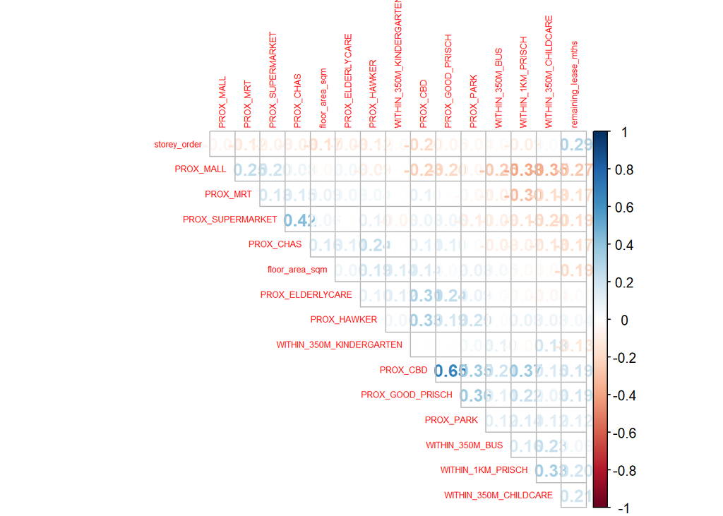

```r
mdata_nogeo <- mdata %>%
  st_drop_geometry()
corrplot::corrplot(cor(mdata_nogeo[, 2:17]),
                   diag = FALSE,
                   order = "AOE",
                   tl.pos = "td",
                   tl.cex = 0.5,
                   method = "number",
                   type = "upper")
```

## 6 **Retrieving the Stored Data**

```r
train_data <- read_rds("data/rds/train_data.rds")
test_data <- read_rds("data/rds/test_data.rds")
```

## 7 **Building a non-spatial multiple linear regression**

```r
price_mlr <- lm(resale_price ~ floor_area_sqm +
                  storey_order + remaining_lease_mths +
                  PROX_CBD + PROX_ELDERLYCARE + PROX_HAWKER +
                  PROX_MRT + PROX_PARK + PROX_MALL +
                  PROX_SUPERMARKET + WITHIN_350M_KINDERGARTEN +
                  WITHIN_350M_CHILDCARE + WITHIN_350M_BUS +
                  WITHIN_1KM_PRISCH,
                data=train_data)
summary(price_mlr)
```

```
Call:
lm(formula = resale_price ~ floor_area_sqm + storey_order + remaining_lease_mths +
    PROX_CBD + PROX_ELDERLYCARE + PROX_HAWKER + PROX_MRT + PROX_PARK +
    PROX_MALL + PROX_SUPERMARKET + WITHIN_350M_KINDERGARTEN +
    WITHIN_350M_CHILDCARE + WITHIN_350M_BUS + WITHIN_1KM_PRISCH,
    data = train_data)

Residuals:
    Min      1Q  Median      3Q     Max
-205193  -39120   -1930   36545  472355

Coefficients:
                           Estimate Std. Error t value Pr(>|t|)
(Intercept)              107601.073  10601.261  10.150  < 2e-16 ***
floor_area_sqm             2780.698     90.579  30.699  < 2e-16 ***
storey_order              14299.298    339.115  42.167  < 2e-16 ***
remaining_lease_mths        344.490      4.592  75.027  < 2e-16 ***
PROX_CBD                 -16930.196    201.254 -84.124  < 2e-16 ***
PROX_ELDERLYCARE         -14441.025    994.867 -14.516  < 2e-16 ***
PROX_HAWKER              -19265.648   1273.597 -15.127  < 2e-16 ***
PROX_MRT                 -32564.272   1744.232 -18.670  < 2e-16 ***
PROX_PARK                 -5712.625   1483.885  -3.850 0.000119 ***
PROX_MALL                -14717.388   2007.818  -7.330 2.47e-13 ***
PROX_SUPERMARKET         -26881.938   4189.624  -6.416 1.46e-10 ***
WITHIN_350M_KINDERGARTEN   8520.472    632.812  13.464  < 2e-16 ***
WITHIN_350M_CHILDCARE     -4510.650    354.015 -12.741  < 2e-16 ***
WITHIN_350M_BUS             813.493    222.574   3.655 0.000259 ***
WITHIN_1KM_PRISCH         -8010.834    491.512 -16.298  < 2e-16 ***
---
Signif. codes:  0 '***' 0.001 '**' 0.01 '*' 0.05 '.' 0.1 ' ' 1

Residual standard error: 61650 on 10320 degrees of freedom
Multiple R-squared:  0.7373,    Adjusted R-squared:  0.737
F-statistic:  2069 on 14 and 10320 DF,  p-value: < 2.2e-16
```

```r
write_rds(price_mlr, "data/rds/price_mlr.rds" )
```

## 8 **Preparing coordinates data**

### 8.1 **Extracting coordinates data**

The code chunk below extract the x,y coordinates of the full, training and test data sets.

```r
coords <- st_coordinates(mdata)
coords_train <- st_coordinates(train_data)
coords_test <- st_coordinates(test_data)
```

Before continue, we write all the output into rds for future used.

```r
coords_train <- write_rds(coords_train, "data/rds/coords_train.rds" )
coords_test <- write_rds(coords_test, "data/rds/coords_test.rds" )
```

### 8.2 **Droping geometry field**

First, we will drop geometry column of the sf data.frame by using `st_drop_geometry()` of sf package.

```r
train_data <- train_data %>%
  st_drop_geometry()
```

## 9 **Calibrating Random Forest Model**

In this section, you will learn how to calibrate a model to predict HDB resale price by using random forest function of [**ranger**](https://cran.r-project.org/web/packages/ranger/index.html) package.

```r
set.seed(1234)
rf <- ranger(resale_price ~ floor_area_sqm + storey_order +
               remaining_lease_mths + PROX_CBD + PROX_ELDERLYCARE +
               PROX_HAWKER + PROX_MRT + PROX_PARK + PROX_MALL +
               PROX_SUPERMARKET + WITHIN_350M_KINDERGARTEN +
               WITHIN_350M_CHILDCARE + WITHIN_350M_BUS +
               WITHIN_1KM_PRISCH,
             data=train_data)
rf
```

```
Ranger result

Call:
 ranger(resale_price ~ floor_area_sqm + storey_order + remaining_lease_mths +      PROX_CBD + PROX_ELDERLYCARE + PROX_HAWKER + PROX_MRT + PROX_PARK +      PROX_MALL + PROX_SUPERMARKET + WITHIN_350M_KINDERGARTEN +      WITHIN_350M_CHILDCARE + WITHIN_350M_BUS + WITHIN_1KM_PRISCH,      data = train_dat…

Type:                             Regression
Number of trees:                  500
Sample size:                      10335
Number of independent variables:  14
Mtry:                             3
Target node size:                 5
Variable importance mode:         none
Splitrule:                        variance
OOB prediction error (MSE):       728602496
R squared (OOB):                  0.9495728
```

```r
write_rds(rf, "data/rds/rf.rds")
```

```r
rf <- read_rds("data/rds/rf.rds")
rf
```

```
Ranger result

Call:
 ranger(resale_price ~ floor_area_sqm + storey_order + remaining_lease_mths +      PROX_CBD + PROX_ELDERLYCARE + PROX_HAWKER + PROX_MRT + PROX_PARK +      PROX_MALL + PROX_SUPERMARKET + WITHIN_350M_KINDERGARTEN +      WITHIN_350M_CHILDCARE + WITHIN_350M_BUS + WITHIN_1KM_PRISCH,      data = train_dat…

Type:                             Regression
Number of trees:                  500
Sample size:                      10335
Number of independent variables:  14
Mtry:                             3
Target node size:                 5
Variable importance mode:         none
Splitrule:                        variance
OOB prediction error (MSE):       728602496
R squared (OOB):                  0.9495728
```

## 10 **Calibrating Geographical Random Forest Model**

In this section, you will learn how to calibrate a model to predict HDB resale price by using `grf()` of [**SpatialML**](https://cran.r-project.org/web/packages/ranger/index.html) package.

### 10.1 **Calibrating using training data**

The code chunk below calibrate a geographic ranform forest model by using `grf()` of **SpatialML** package.

```r
set.seed(1234)
gwRF_adaptive <- grf(formula = resale_price ~ floor_area_sqm + storey_order +
                       remaining_lease_mths + PROX_CBD + PROX_ELDERLYCARE +
                       PROX_HAWKER + PROX_MRT + PROX_PARK + PROX_MALL +
                       PROX_SUPERMARKET + WITHIN_350M_KINDERGARTEN +
                       WITHIN_350M_CHILDCARE + WITHIN_350M_BUS +
                       WITHIN_1KM_PRISCH,
                     dframe=train_data,
                     bw=55,
                     kernel="adaptive",
                     coords=coords_train)
```

```
Number of Observations: 10335
```

```
Number of Independent Variables: 14
```

```
Kernel: Adaptive
Neightbours: 55
```

```
--------------- Global ML Model Summary ---------------
```

```
Ranger result

Call:
 ranger(resale_price ~ floor_area_sqm + storey_order + remaining_lease_mths +      PROX_CBD + PROX_ELDERLYCARE + PROX_HAWKER + PROX_MRT + PROX_PARK +      PROX_MALL + PROX_SUPERMARKET + WITHIN_350M_KINDERGARTEN +      WITHIN_350M_CHILDCARE + WITHIN_350M_BUS + WITHIN_1KM_PRISCH,      data = train_dat…

Type:                             Regression
Number of trees:                  500
Sample size:                      10335
Number of independent variables:  14
Mtry:                             4
Target node size:                 5
Variable importance mode:         impurity
Splitrule:                        variance
OOB prediction error (MSE):       700081018
R squared (OOB):                  0.9515468
```

```
Importance:
```

```
          floor_area_sqm             storey_order     remaining_lease_mths
            7.376510e+12             1.413229e+13             2.991844e+13
                PROX_CBD         PROX_ELDERLYCARE              PROX_HAWKER
            5.312697e+13             7.017513e+12             5.506719e+12
                PROX_MRT                PROX_PARK                PROX_MALL
            7.446857e+12             4.825986e+12             4.173165e+12
        PROX_SUPERMARKET WITHIN_350M_KINDERGARTEN    WITHIN_350M_CHILDCARE
            2.879598e+12             1.028775e+12             1.701318e+12
         WITHIN_350M_BUS        WITHIN_1KM_PRISCH
            1.564038e+12             7.214027e+12
```

```
Mean Square Error (Not OOB): 173279991.32
```

```
R-squared (Not OOB) %: 98.801
```

```
AIC (Not OOB): 196089.283
```

```
AICc (Not OOB): 196089.33
```

```
--------------- Local Model Summary ---------------
```

```
Residuals OOB:
```

```
     Min.   1st Qu.    Median      Mean   3rd Qu.      Max.
-236112.0  -13033.7     444.4     593.8   14831.5  358041.7
```

```
Residuals Predicted (Not OOB):
```

```
     Min.   1st Qu.    Median      Mean   3rd Qu.      Max.
-79279.83  -3510.70     54.56     50.98   3909.85  83074.08
```

```
Local Variable Importance:
```

```
                               Min          Max        Mean         StD
floor_area_sqm                   0 401562922035 18210850992 41426270899
storey_order             302736445 243728744368 16368419468 23620589843
remaining_lease_mths     696564138 546463600727 34119912443 70328183398
PROX_CBD                  55173040 382484896335 12154563393 29293290548
PROX_ELDERLYCARE          45182031 344081962746 10597657883 24546405941
PROX_HAWKER               43516026 342597797419 10551807020 23408387903
PROX_MRT                  54234551 299075025906  9873129985 21055852211
PROX_PARK                 49919822 322633843469  9353956995 19517077658
PROX_MALL                 43296133 433263607933 11247374493 27537334970
PROX_SUPERMARKET          52665827 417310417234 10802122271 26572460731
WITHIN_350M_KINDERGARTEN         0 186468064682  2848177740 12928886968
WITHIN_350M_CHILDCARE            0 255236737234  5526292324 18109971102
WITHIN_350M_BUS                  0 193828795378  4747552546 11886064288
WITHIN_1KM_PRISCH                0 178360608427  1778262602  7163381668
```

```
Mean squared error (OOB): 930426169.333
```

```
R-squared (OOB) %: 93.56
```

```
AIC (OOB): 213459.669
```

```
AICc (OOB): 213459.716
```

```
Mean squared error Predicted (Not OOB): 73859413.696
```

```
R-squared Predicted (Not OOB) %: 99.489
```

```
AIC Predicted (Not OOB): 187276.161
```

```
AICc Predicted (Not OOB): 187276.208
```

```
Calculation time (in seconds): 3.2945
```

Let’s save the model output by using the code chunk below.

```r
write_rds(gwRF_adaptive, "data/rds/gwRF_adaptive.rds")
```

The code chunk below can be used to retrieve the save model in future.

```r
gwRF_adaptive <- read_rds("data/rds/gwRF_adaptive.rds")
```

### 10.2 **Predicting by using test data**

#### Preparing the test data

The code chunk below will be used to combine the test data with its corresponding coordinates data.

```r
test_data <- cbind(test_data, coords_test) %>%
  st_drop_geometry()
```

#### Predicting with test data

Next, `predict.grf()` of spatialML package will be used to predict the resale value by using the test data and gwRF_adaptive model calibrated earlier.

```r
gwRF_pred <- predict.grf(gwRF_adaptive,
                           test_data,
                           x.var.name="X",
                           y.var.name="Y",
                           local.w=1,
                           global.w=0)
```

Before moving on, let us save the output into rds file for future use.

```r
GRF_pred <- write_rds(gwRF_pred, "data/rds/GRF_pred.rds")
```

#### Converting the predicting output into a data frame

The output of the `predict.grf()` is a vector of predicted values. It is wiser to convert it into a data frame for further visualisation and analysis.

```r
GRF_pred <- read_rds("data/rds/GRF_pred.rds")
GRF_pred_df <- as.data.frame(GRF_pred)
```

In the code chunk below, `cbind()` is used to append the predicted values onto test_data

```r
test_data_p <- cbind(test_data, GRF_pred_df)
```

```r
write_rds(test_data_p, "data/rds/test_data_p.rds")
```

### 10.3 **Calculating Root Mean Square Error**

The root mean square error (RMSE) allows us to measure how far predicted values are from observed values in a regression analysis. In the code chunk below, rmse() of Metrics package is used to compute the RMSE.

```r
rmse(test_data_p$resale_price,
     test_data_p$GRF_pred)
```

```
[1] 27302.9
```

### 10.4 **Visualising the predicted values**

Alternatively, scatterplot can be used to visualise the actual resale price and the predicted resale price by using the code chunk below.

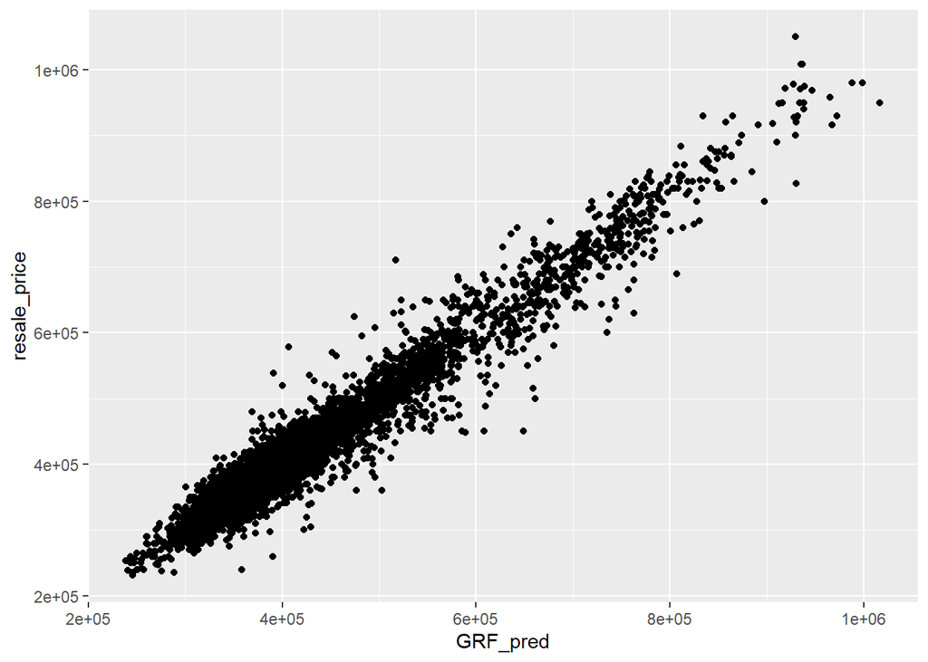

```r
ggplot(data = test_data_p,
       aes(x = GRF_pred,
           y = resale_price)) +
  geom_point()
```

A better predictive model should have the scatter point close to the diagonal line. The scatter plot can be also used to detect if any outliers in the model.